# Topic Models

BDS

We already know that text is everywhere and our sentiment analysis was a reasonable crack at extracting some meaning from text. A common line of inquiry relates to what is expressed within the text. In traditionally social sciences, this was done through some form of content analysis – a coding scheme was developed by researchers, people read each comment and assigned it a code, some agreement statistics were computed, and any discrepencies were hashed out by the researchers. When this was the only option, it was servicable. Could you do this for thousands of tweets? With time, maybe. Could you do this with a few million articles? No. This is where topic models, and latent dirichlet allocation, come to save the day.

## Latent Dirichlet Allocation

- $\alpha$ is the parameter of the Dirichlet prior on the per-document topic distributions
- $\eta$ is the parameter of the Dirichlet prior on the per-topic word distribution
- $\theta_m$θm is the topic distribution for document m
- $\beta_k$ is the word distribution for topic k
- $z_{mn}$ is the topic for the n-th word in document m
- $w_{mn}$ is the specific word

Both *z* and *w* are from a multinomial draw based on the θ and β distributions respectively. The key idea is that, to produce a given document, one draws a topic, and given the topic, words are drawn from it.

## Generating Documents

In the standard setting, to be able to conduct such an analysis from text, one needs a document-term matrix, where rows represent documents, and columns terms. Terms are typically words but could be any n-gram of interest. In practice, this is where you’ll spend most of your time, as text is never ready for analysis, and must be scraped, converted, stemmed, cleaned etc. We will initially create θ and β noted above, then given those, draw topics and words given topics based on the multinomial distribution.

## Topic Probabilities

We begin the simulation by creating topic probabilities. There will be *k* = 3 topics. Half of our documents will have probabilities of topics for them ($\theta1$) which will be notably different from the other half ($\theta2$). Specifically, the first half will show higher probability of topic “A” and “B”, while the second half of documents show higher probability of topic “C”. What we’ll end up with here is an m X k matrix of probabilities θ where each m document has a non-zero probability for each k topic. Note that in the plate diagram, these would come from a Dirichlet(α) draw rather than be fixed like this, but hopefully this will make things clear starting out.

```r
library(tidyverse)

nDocs = 500                                       # Number of documents

wordsPerDoc = rpois(nDocs, 100)                   # Total words/terms in a document

thetaList = list(c(A = .60, B = .25, C = .15),    # Topic proportions for first and second half of data
                 c(A = .10, B = .10, C = .80))    # These values represent a Dir(alpha) draw

theta_1 = t(replicate(nDocs / 2, thetaList[[1]]))

theta_2 = t(replicate(nDocs / 2, thetaList[[2]]))

theta = rbind(theta_1, theta_2)
```

## Topic Assignments and Labels

With topic probabilities in hand, we’ll draw topic assignments from a categorical distribution.

```r
firsthalf = 1:(nDocs / 2)
secondhalf = (nDocs / 2 + 1):nDocs

Z = apply(theta, 1, rmultinom, n = 1, size = 1)   # draw topic assignment

rowMeans(Z[, firsthalf])                           # roughly equal to theta_1
```

```
## [1] 0.588 0.232 0.180
```

Now, we can see which is the most likely topic.

```r
z = apply(Z, 2, which.max)
```

We have our list of documents and each document’s topic assignment.

## Topics

Next we need the topics themselves. Topics are probability distributions of terms, and in what follows we’ll use the Dirichlet distribution to provide the prior probabilities for the terms. With topic A, we’ll make the first ~40% of terms have a higher probability of occurring, the last ~40% go with topic C, and the middle more associated with topic B. To give a sense of the alpha settings, alpha = c(8, 1, 1) would result in topic probabilities of .8, .1, .1, as would alpha = c(80, 10, 10). We’ll use the gtools package for the rdirichlet function.

```r
nTerms = max(wordsPerDoc)

breaks = quantile(1:nTerms, c(.4,.6,1)) %>% round()

cuts = list(1:breaks[1], (breaks[1] + 1):breaks[2],
            (breaks[2] + 1):nTerms)

library(gtools)

B_k = matrix(0, ncol = 3, nrow = nTerms)

B_k[,1] = rdirichlet(n=1, alpha=c(rep(10, length(cuts[[1]])),    # topics for 1st 40% of terms
                                  rep(1,  length(cuts[[2]])),
                                  rep(1,  length(cuts[[3]]))))

B_k[,2] = rdirichlet(n=1, alpha=c(rep(1,  length(cuts[[1]])),    # topics for middle 20%
                                  rep(10, length(cuts[[2]])),
                                  rep(1,  length(cuts[[3]]))))

B_k[,3] = rdirichlet(n=1, alpha=c(rep(1,  length(cuts[[1]])),    # topics for last 40%
                                  rep(1,  length(cuts[[2]])),
                                  rep(10, length(cuts[[3]]))))
```

Here is a visualization of the term-topic matrix, where the dark represents terms that are notably less likely to be associated with a particular topic.

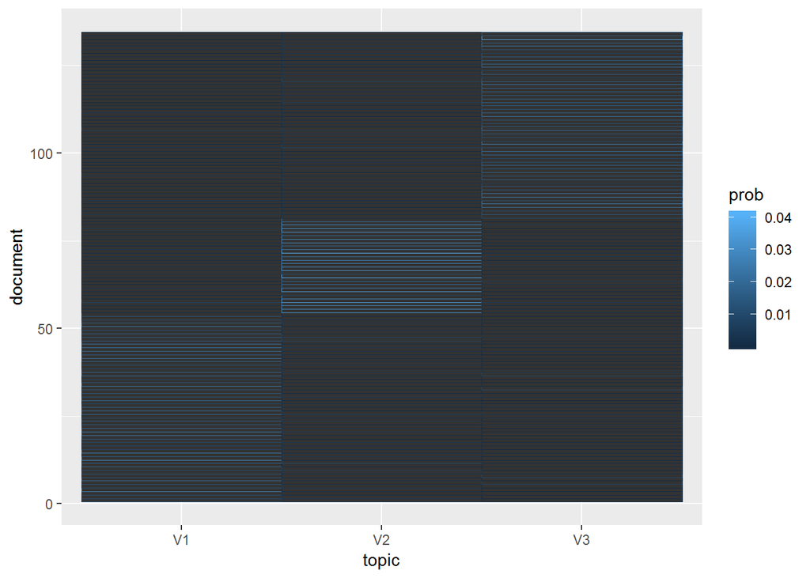

```r
library(ggplot2)

as.data.frame(B_k) %>%
  mutate(document = 1:nrow(.)) %>%
  tidyr::gather(key = topic, value = prob, -document) %>%
  ggplot(., aes(topic, document, color = prob)) +
  geom_tile()
```

Remember how we specified this – we assigned 40% to topic 1, 40% to topic 3, and left the middle 20% to topic 2. This visualization clearly shows this.

Now, given the topic assignment, we draw words for each document according to its size via a multinomial draw, and with that, we have our document-term matrix. However, we can also think of each document as merely a bag of words, where order, grammar etc. is ignored, but the frequency of term usage is retained.

```r
wordlist_1 = sapply(1:nDocs,
                    function(i) t(rmultinom(1, size = wordsPerDoc[i], prob = B_k[, z[i]])),
                    simplify = FALSE)

# smash to doc-term matrix
dtm_1 = do.call(rbind, wordlist_1)

colnames(dtm_1) = paste0('word', 1:nTerms)

# bag of words representation
wordlist_1 = lapply(wordlist_1, function(wds) rep(paste0('word', 1:length(wds)), wds))
```

If you print out the wordlist_1 object, you will see the words asssociated with each document.

## Topic Models

Now with some theory under our belt, we can take a look at analyzing some data. Just to keep everything light, we will be looking at the Last Statement of inmates executed in Texas.

Just like our sentiment analysis, there is a fair chunk of cleaning to do:

```r
library(stm)

executions = read.csv("txEx.csv", stringsAsFactors = FALSE)

executionsText = textProcessor(documents = executions$correctedStatements,
                           metadata = executions)
```

```
## Building corpus...
## Converting to Lower Case...
## Removing punctuation...
## Removing stopwords...
## Removing numbers...
## Stemming...
## Creating Output...
```

```r
executionsPrep = prepDocuments(documents = executionsText$documents,
                               vocab = executionsText$vocab,
                               meta = executionsText$meta)
```

```
## Removing 1240 of 2305 terms (1240 of 12857 tokens) due to frequency
## Your corpus now has 425 documents, 1065 terms and 11617 tokens.
```

The stm package has some pretty nice facilities for determining a number of topics:

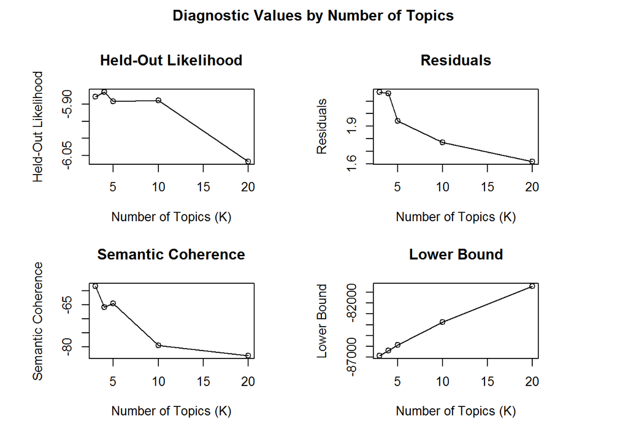

```r
kTest = searchK(documents = executionsPrep$documents,
             vocab = executionsPrep$vocab,
             K = c(3, 4, 5, 10, 20), verbose = FALSE)

plot(kTest)
```

The 4 plots that are returned are going to try to help us determine the best number of topics to take. I like to focus on semantic coherence (how well the words hang together) and the residuals. We want to have low residual and high semantic coherence. The residuals definitely take a sharp dive as we increase K. If we consider one of the major assumptions of LDA, we could almost always guess that we would need a great number of topics (i.e., if every topic that has ever existed, existed before writing, then we could have a huge numebr of topics). Our coherence seems to do pretty well with some of the lower numbers (not entirely surprising). With all of these together, we can settle on 5 topics for our subsequent analyses.

It is worthwhile to note that we can also do model selection with the stm package, but that is some work that will be best done if you want some additional playtime.

With our 5 topics, we can start our actual model:

```r
topics5 = stm(documents = executionsPrep$documents,
             vocab = executionsPrep$vocab,
             K = 5, verbose = FALSE)
```

We can get a lot of output from our model, but we can focus on the expected topic proportions plot:

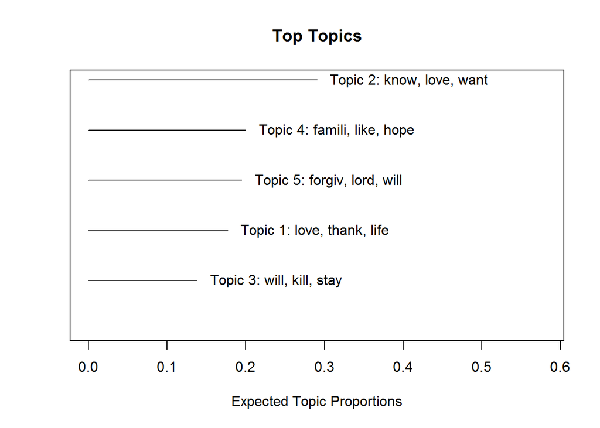

```r
plot(topics5)
```

We are essentially looking at the proportion of each topic, with a few of the highest probability words.

This is great, but it is really fun to see what emerges from the topics.

```r
labelTopics(topics5)
```

```
## Topic 1 Top Words:
##       Highest Prob: love, thank, life, support, peopl, way, brother
##       FREX: live, allah, appreci, thank, bye, row, learn
##       Lift: cousin, maria, mauri, open, pam, within, afford
##       Score: thank, love, bye, allah, support, appreci, live
## Topic 2 Top Words:
##       Highest Prob: know, love, want, yall, say, sorri, dont
##       FREX: alright, watch, dont, worri, mom, tell, care
##       Lift: alba, ass, daddi, fall, fault, folk, forc
##       Score: yall, dont, love, kid, sorri, tell, care
## Topic 3 Top Words:
##       Highest Prob: will, kill, stay, peopl, innoc, murder, get
##       FREX: kill, innoc, murder, must, stop, justic, fight
##       Lift: adam, bed, church, dna, error, forgotten, heard
##       Score: kill, black, polic, innoc, must, evid, america
## Topic 4 Top Words:
##       Highest Prob: famili, like, hope, peac, god, one, friend
##       FREX: receiv, famili, friend, peac, victim, like, mother
##       Lift: behalf, behold, final, grate, knowledg, known, lay
##       Score: peac, like, famili, god, rejoic, unto, propheci
## Topic 5 Top Words:
##       Highest Prob: forgiv, lord, will, god, sorri, jesus, ask
##       FREX: forgiv, sin, thi, holi, prais, amen, accept
##       Lift: accept, action, anointest, bread, comfort, etern, everlast
##       Score: forgiv, thi, holi, thou, lord, jesus, amen
```

Let’s focus on the frex words (they occur *fr*equently within the topic and are *ex*clusive to that topic) and the highest probability words (i.e., the words that have the highest probability of occuring within that topic). The Lift and Score words (just a few different ways of weighting occurance) can be useful, but are a bit less intuitive than the other two. Let’s put some names to the topics. Topic 1 is likely expressing “thanks for the love and the support”, topic 2 is something along the lines of “everything is going to be alright”, topic 3 is “you are murdering an innocent man”, topic 4 is probably “I hope your family finds peace”, and topic 5 is “I hope God forgives me”.

We can look at statements that have a high probability of being associated with each topic:

```r
findThoughts(topics5, texts = executionsPrep$meta$correctedStatements, n = 1)
```

```
##
##  Topic 1:
##       I would like to extend my love to my family members and my relatives for all of the love and support you have showed me. I extend my special love to my daughter who I love greatly. I hope that you forever remember me. I hope that you will always cherish the love and the strength that I have…
##  Topic 2:
##       Hey, how y'all doing out there? I done lost my voice. Y'all be strong now, alright? Don, thanks man. I love you, Gloria, always baby. That's all I got to say. Hey, don't y'all worry about me, okay?
##  Topic 3:
##       I would like to say first of all the real violent crimes in this case are acts committed by James Boswell and Clay Morgan Gaines. We have the physical evidence to prove fabrication and cover-up. The people responsible for killing me will have blood on their hands for an unprovoked murder. I…
##  Topic 4:
##       The following is the personal final statement of and by Michael L. McBride. The Beatitudes: Jesus lifted up his eyes on His disciples, and said, "Blessed be the poor: for yours is the kingdom of God. Blessed are ye that hunger now: for ye shall be filled. Blessed are ye that weep now: for y…
##  Topic 5:
##       Mama Isabel told me to tell you hello. Holy, holy, holy! Lord God Almighty! Early in the morning our song shall rise to Thee; Holy, holy, holy, merciful and mighty! God in three Persons, blessed Trinity. Holy, holy, holy! Merciful and mighty. All Thy works shall praise Thy name, in earth, a…
```

We can see that the story we put to our topics makes sense, given what we see in the actual texts.